# Entwurf: Quantifizierung und regionale Trends des Facharztmangels im Öffentlichen Gesundheitsdienst (ÖGD)

Peter Tinnemann, Jakob Schumacher, Elke Bruns-Philipps, Ute Teichert

11 Mai 2019

## Datenquelle

Die Daten stammen von den Ärztekammern. Sie werden bereitgestellt auf www.gbe-bund.de unter dem Tabellennamen: “Ärztinnen und Ärzte mit Gebiets- und Facharztbezeichnung, BÄK”

Beschreibung der Methodik der Statistik der Mitglieder der (Landes-) Ärztekammern (Ärztestatistik) von gbe-bund.de * *In den Heilberufsgesetzen der Bundesländer ist festgelegt, dass alle Ärzte, die in einem bestimmten Bundesland tätig sind oder, falls sie ihren Beruf nicht ausüben, ihren gewöhnlichen Aufenthalt haben, Mitglied der jeweiligen (Landes-) Ärztekammer sein müssen. Die Kammern haben über ihre Mitglieder ein Verzeichnis zu führen, in das bestimmte Angaben einzutragen sind. Auf der Basis dieser Mitgliederverzeichnisse erstellen die (Landes-) Ärztekammern zum 31. Dezember jeden Jahres Auswertungen zu ausgewählten Aspekten der Berufspolitik, die sie an die Bundesärztekammer weiterleiten. Die Bundesärztekammer (BÄK), Arbeitsgemeinschaft der deutschen Ärztekammern, ist die Berufsvertretung aller deutschen Ärzte auf Bundesebene. Die Bundesärztekammer fasst diese Meldungen zum Bundesergebnis zusammen und erstellt somit die Ärztestatistik.*

Beschreibung der Auswahl 1. Auswahl der Tabelle “Ärztinnen und Ärzte mit Gebiets- und Facharztbezeichnung, BÄK” auf GBE-Bund.de 2. Einschränkung auf der Seite “Werteauswahl” auf die Jahre 1998 bis 2018 3. Wenn “alle Facharztrichtungen” beschrieben sind wurde auf der Seite “Werteauswahl” die folgenden ausgewählt: Allgemeinmedizin, Anästhesiologie, Anatomie, Arbeitsmedizin, Augenheilkunde, Biochemie, Chirurgie, Frauenheilkunde und Geburtshilfe, Hals-Nasen-Ohrenheilkunde, Haut- und Geschlechtskrankheiten, Humangenetik, Hygiene und Umweltmedizin, Innere Medizin, Kinder- und Jugendmedizin, Kinder- und Jugendpsychiatrie und -psychotherapie, Laboratoriumsmedizin, Mikrobiologie Virologie Infektionsepidemiologie, Mund-Kiefer-Gesichtschirurgie, Neurochirurgie, Neurologie, Nuklearmedizin, Öffentliches Gesundheitswesen, Pathologie, Pharmakologie, Physikalische und Rehabilitative Medizin, Physiologie, Psychiatrie und Psychotherapie, Psychosomatische Medizin und Psychotherapie, Radiologie, Rechtsmedizin, Strahlentherapie, Transfusionsmedizin, Urologie 4. Wenn “Fachärzte im öffentlichen Gesundheitswesen” beschrieben ist wurde nur auf der Seite “Werteauswahl” ausgewählt: Öffentliches Gesundheitswesen 2. Wenn “tätigen” Fachärzten beschrieben sind, wurde unter “Diese Tabelle bezieht sich auf folgende Blattmerkmale” und “Tätigkeitsbereiche” die Auswahl “mit ärztlicher Tätigkeit” getroffen

# Abbildung 1: Kummulierte prozentuale Änderung der Anzahl an tätigen Fachärzt/innen von 1998 bis 2018 nach Ärztlicher Tätigkeit unterschieden zwischen Gesamtheit aller Facharztrichtungen, in Behöroden/Körperschaften o.ä. und Öffentliches Gesundheitswesen

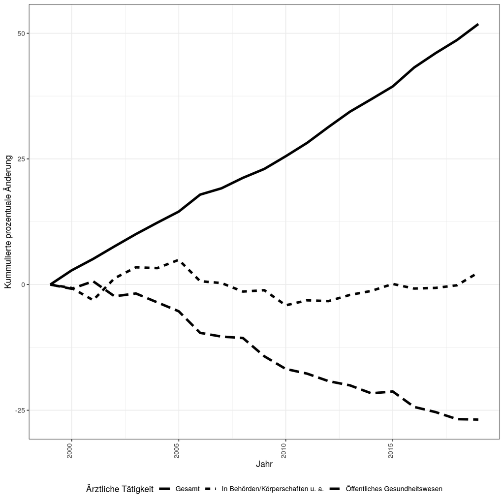

# Tabelle 1: Kummulierte prozentuale Änderung der Anzahl an tätigen Fachärzt/innen von 1998 bis 2018 nach Ärztlicher Tätigkeit unterschieden zwischen Gesamtheit aller Facharztrichtungen, in Behöroden/Körperschaften o.ä. und Öffentliches Gesundheitswesen

| Ärztliche Tätigkeit | 2018 | 1998 | Prozentuale Veränderung |
| --- | --- | --- | --- |
| Gesamt | 274252 | 180624 | 52 |
| In Behörden/Körperschaften u. a. | 6470 | 6319 | 2 |
| Öffentliches Gesundheitswesen | 784 | 1072 | -27 |

# Abbildung 2: Bei den Ärztekammern registrierte tätigen Ärztinnen und Ärzte mit Facharztbezeichnung Öffentliches Gesundheitswesen nach Region von 1998 bis 2018 in Deutschland

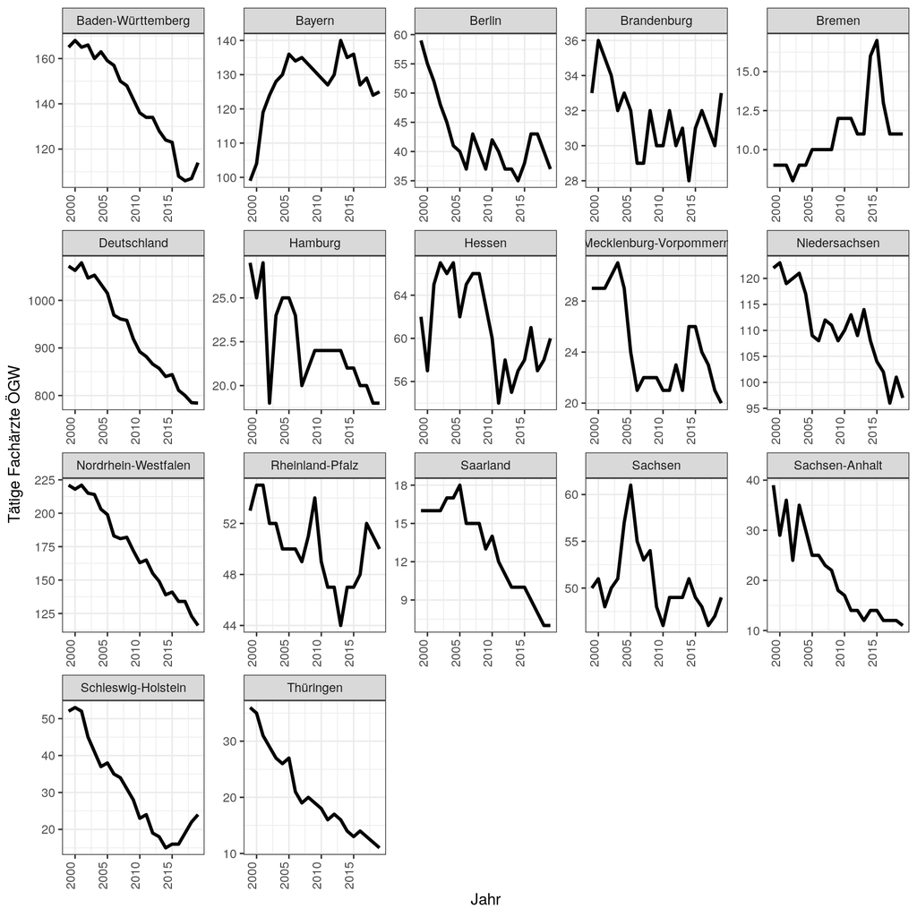

# Tabelle 2: Bei den Ärztekammern registrierte tätigen Ärztinnen und Ärzte mit Facharztbezeichnung Öffentliches Gesundheitswesen nach Region von 1998 bis 2018 in Deutschland

| Region | 1998-12-31 | 1999-12-31 | 2000-12-31 | 2001-12-31 | 2002-12-31 | 2003-12-31 | 2004-12-31 | 2005-12-31 | 2006-12-31 | 2007-12-31 | 2008-12-31 | 2009-12-31 | 2010-12-31 | 2011-12-31 | 2012-12-31 | 2013-12-31 | 2014-12-31 | 2015-12-31 | 2016-12-31 | 2017-12-31 | 2018-12-31 |
| --- | --- | --- | --- | --- | --- | --- | --- | --- | --- | --- | --- | --- | --- | --- | --- | --- | --- | --- | --- | --- | --- |
| Deutschland | 1072 | 1063 | 1079 | 1047 | 1053 | 1034 | 1015 | 969 | 961 | 958 | 919 | 892 | 882 | 866 | 857 | 840 | 844 | 811 | 800 | 785 | 784 |
| Nordrhein-Westfalen | 221 | 218 | 221 | 215 | 214 | 203 | 199 | 183 | 181 | 182 | 172 | 163 | 165 | 155 | 149 | 139 | 141 | 134 | 134 | 123 | 116 |
| Baden-Württemberg | 165 | 168 | 165 | 166 | 160 | 163 | 159 | 157 | 150 | 148 | 142 | 136 | 134 | 134 | 128 | 124 | 123 | 108 | 106 | 107 | 114 |
| Bayern | 99 | 104 | 119 | 124 | 128 | 130 | 136 | 134 | 135 | 133 | 131 | 129 | 127 | 130 | 140 | 135 | 136 | 127 | 129 | 124 | 125 |
| Niedersachsen | 122 | 123 | 119 | 120 | 121 | 117 | 109 | 108 | 112 | 111 | 108 | 110 | 113 | 109 | 114 | 108 | 104 | 102 | 96 | 101 | 97 |
| Hessen | 62 | 57 | 65 | 67 | 66 | 67 | 62 | 65 | 66 | 66 | 63 | 60 | 54 | 58 | 55 | 57 | 58 | 61 | 57 | 58 | 60 |
| Sachsen | 50 | 51 | 48 | 50 | 51 | 57 | 61 | 55 | 53 | 54 | 48 | 46 | 49 | 49 | 49 | 51 | 49 | 48 | 46 | 47 | 49 |
| Rheinland-Pfalz | 53 | 55 | 55 | 52 | 52 | 50 | 50 | 50 | 49 | 51 | 54 | 49 | 47 | 47 | 44 | 47 | 47 | 48 | 52 | 51 | 50 |
| Berlin | 59 | 55 | 52 | 48 | 45 | 41 | 40 | 37 | 43 | 40 | 37 | 42 | 40 | 37 | 37 | 35 | 38 | 43 | 43 | 40 | 37 |
| Schleswig-Holstein | 52 | 53 | 52 | 45 | 41 | 37 | 38 | 35 | 34 | 31 | 28 | 23 | 24 | 19 | 18 | 15 | 16 | 16 | 19 | 22 | 24 |
| Brandenburg | 33 | 36 | 35 | 34 | 32 | 33 | 32 | 29 | 29 | 32 | 30 | 30 | 32 | 30 | 31 | 28 | 31 | 32 | 31 | 30 | 33 |
| Sachsen-Anhalt | 39 | 29 | 36 | 24 | 35 | 30 | 25 | 25 | 23 | 22 | 18 | 17 | 14 | 14 | 12 | 14 | 14 | 12 | 12 | 12 | 11 |
| Hamburg | 27 | 25 | 27 | 19 | 24 | 25 | 25 | 24 | 20 | 21 | 22 | 22 | 22 | 22 | 22 | 21 | 21 | 20 | 20 | 19 | 19 |
| Mecklenburg-Vorpommern | 29 | 29 | 29 | 30 | 31 | 29 | 24 | 21 | 22 | 22 | 22 | 21 | 21 | 23 | 21 | 26 | 26 | 24 | 23 | 21 | 20 |
| Thüringen | 36 | 35 | 31 | 29 | 27 | 26 | 27 | 21 | 19 | 20 | 19 | 18 | 16 | 17 | 16 | 14 | 13 | 14 | 13 | 12 | 11 |
| Saarland | 16 | 16 | 16 | 16 | 17 | 17 | 18 | 15 | 15 | 15 | 13 | 14 | 12 | 11 | 10 | 10 | 10 | 9 | 8 | 7 | 7 |
| Bremen | 9 | 9 | 9 | 8 | 9 | 9 | 10 | 10 | 10 | 10 | 12 | 12 | 12 | 11 | 11 | 16 | 17 | 13 | 11 | 11 | 11 |